# Predicting Policy Domains and Preferences with BERT and Convolutional Neural Networks

Natural Language Processing with Deep Learning

We present a deep learning approach to classifying labeled texts and phrases in party manifestos, using the coding scheme and documents from the Manifesto Project Corpus.

Allison Koh http://allisonkoh.github.io , Daniel Kai Sheng Boey  
10-10-2020

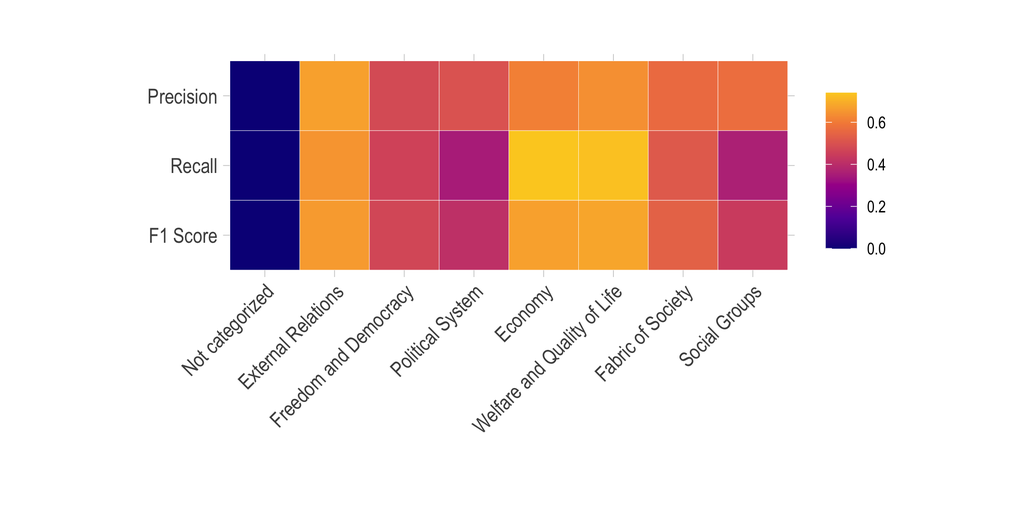

## Background

During campaigns, political actors communicate their position on a range of key issues to signal campaign promises and gain favor with constituents. Whilst identifying the political positions of political actors provides no certainty with regards to whether they act upon their policy preferences, it remains essential to understanding their intended political actions. Quantitative methods, especially in the field of natural language processing, have enabled the development of more scalable methods for predicting policy preferences. These advancements have enabled political scientists to analyze political texts and estimate their positions over time (Nanni et al. 2016; Zirn et al. 2016). To better understand the political positions of political actors, many social science researchers have turned to hand-labeling political documents, such as parliamentary debate motions and party manifestos. Much of the previous work on analyzing political texts relies on hand-labeling documents (Abercrombie and Batista-Navarro 2018; Gilardi, Füglister, and Luyet 2009; Krause 2011; Simmons and Elkins 2004). Yet, the analysis of political documents in this field stands to benefit from automating the coding of texts using supervised machine learning. Most recently, neural networks and deep language representation models have been employed in state-of-the-art approaches to automatic labeling of political texts by policy preference.

## Related Work

Several studies have concentrated on building scaling models that identify the political position of texts (Glavaš, Nanni, and Ponzetto 2017; Laver, Benoit, and Garry 2003; Nanni et al. 2019; Proksch and Slapin 2010). Previously, most of the seminal work in this area has overlooked the task of classifying texts by topic or policy area prior to detecting policy preferences associated with the topic. Over the past couple of years, several studies have addressed the gap in *opinion-topic identification* by classifying text data from political speeches, manifestos, and other documents by topic before predicting policy preference. Perhaps most relevant to our research is the paper by Zirn et al. (2016), in which the authors trained and validated an approach to classifying manifestos from the United States into seven policy domains that involved binary classifiers predicting whether sentences that are adjacent to one another belong to the same topic[^1]. Their proposed approach of optimizing predictions using a Markov Logic framework yielded an average micro-F1 score of .749. Glavaš, Nanni, and Ponzetto (2017) introduced a multi-lingual classifier for automatically labeling texts by policy domain. For classification of 20,196 English-language manifestos by policy domain, their CNN models yielded an average micro-F1 score of .59.

Abercrombie et al. (2019) (Abercrombie et al. 2019) used deep language representation models to detect the policy positions of Members of Parliament in the United Kingdom. Using motions and manifestos as data sources, the authors employed a variety of methods to predict the policy and domain labels of texts. They propose utilizing BERT for this task, with results fine-tuned with party manifestos and the motions themselves. In addition to a final softmax layer, the authors added a CNN model and max-pooling layers to the soft-max layer. they found that the use of BERT demonstrated state-of-the-art performance on both manifestos and motions via supervised pipelines with a Macro-F1 score of 0.69 for their best performing model. Our work builds on some of the methods proposed in their paper, leveraging neural networks and deep language representation models for classifying political texts.

## The Manifesto Project Corpus

The Manifesto Project Corpus[^2] provides information on policy preferences of political parties from seven different countries based on a coding scheme of 8 policy domains, under which 58 policy preference codes are manually coded[^3]. The Manifesto Project offers data that divides party manifestos into quasi-sentences, or individual statements which do not span more than one grammatical sentence. Quasi-sentences are then individually assigned to categories pertaining to policy domain and preference. The 58 policy preference codes, one of which is “not categorized,” refer to the position—positive or negative—of a party regarding a particular policy area. The 58 policy preference codes fall into a macro-level coding scheme comprising of 8 policy domain categories. In political science research, the Manifesto Project Corpus is particularly useful for studying party competition, the responsiveness of political parties to constituent preferences, and estimating the ideological position of political elites. While the official classification of manifestos in this dataset has primarily relied on human coders, the investigation of automatically detecting policy positions of the text data is valuable for scaling up the classification of large volumes of political texts available for analysis.

Each of domain comprises of minor categories, also known as [policy preferences](https://manifesto-project.wzb.eu/down/data/2020a/codebooks/codebook_MPDataset_MPDS2020a.pdf). For instance, the policy preferences listed under the “External Relations” domain include:

- Foreign Special Relationships
- Anti-Imperialism
- Military
- Peace
- Internationalism
- European Community/Union

Our final subset of all English-language manifestos comprises of 99,681 quasi-sentences. Figures 1 and 2 illustrate the distribution of English-language manifestos across countries and policy domains. To ensure that the ratio between policy domains remains consistent across all categories in running our models, we applied a 70/15/15 split between training, validation, and test sets separately for all policy domains (major categories) and policy preferences (minor categories).

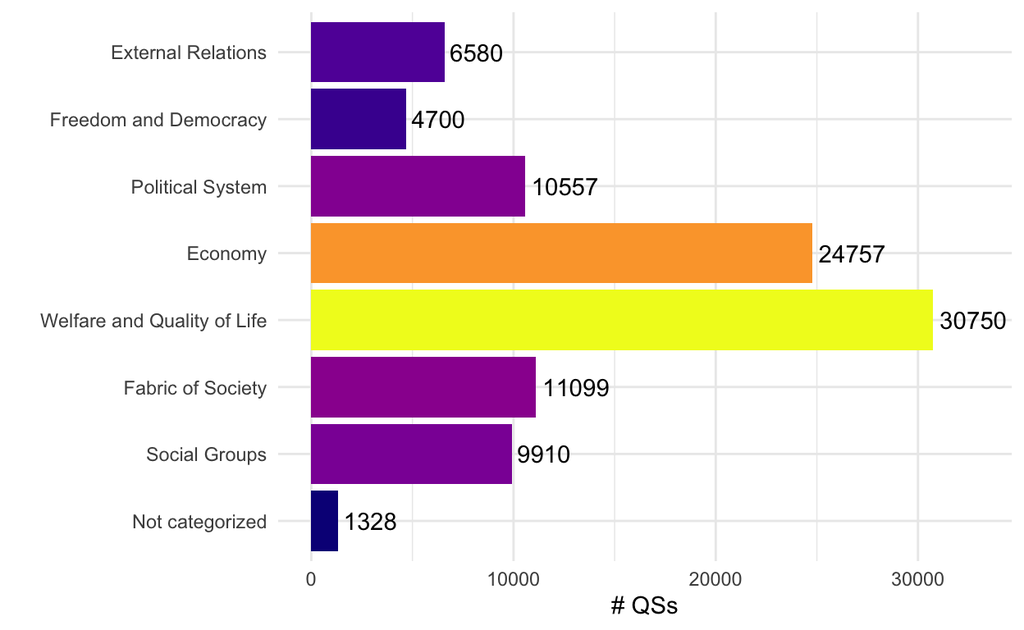

Figure 1: Quasi-sentences (QSs) from English language manifestos by policy domain

[figure not shown]

Figure 2: Quasi-sentences (QSs) from English language manifestos by country

## Experimental Setup

### Bidirectional Encoder Representations from Transformers (BERT)

Bidirectional Encoder Representations from Transformers (BERT) have proven successful in prior attempts to classify phrases and short texts (Devlin et al. 2018). BERT’s key innovation lies in its ability to apply bidirectional training of transformers to language modeling. This state-of-the-art deep language representation model uses a “masked language model,” enabling it to overcome restrictions caused by the unidirectional constraint.

Our experiments use the standard pre-trained BERT transformers as the embedding layer in our model. Since BERT is trained on sequences with a maximum lengths of 512 tokens, all quasi-sentences with more than 510 words were trimmed to fit this requirement. Pre-trained embeddings were frozen and not trained for the base models. We test two variants of BERT—one incorporating a bidirectional GRU model, and another incorporating CNNs. Model specifications and training times for our neural networks and deep language representation models are shown in Table 1 and Figure 3.

Table 1: Model specifications of neural networks and deep language representation models

| Models | Text Representation | Layers | Epochs |
| --- | --- | --- | --- |
| CNN | GloVe Wikipedia w-emb | 2 Convolutional Layers (1 per filter) 2 Max Pooling Layers 1 Dropout Layer 1 Linear Layer | 100 |
| BERT-CNN | Base BERT (uncased) | 2 Convolutional Layers (1 per filter) 2 Max Pooling Layers 1 Dropout Layer 1 Linear Layer | 10 |
| BERT-GRU | Base BERT (uncased) | 1 Bidirectional GRU RNN Layer 1 Dropout Layer 1 Linear Layer | 10 |

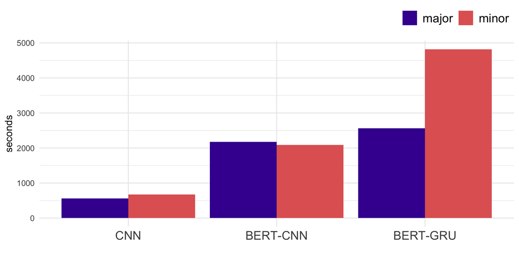

Figure 3: Training time for neural networks and deep language representation models for classifying political texts by *major* and *minor* policy domain

### BERT with Gated Recurrent Units (GRU)

First proposed by Cho et al. (2014) (Cho et al. 2014), Gated Recurrent Units—formerly referred to as the RNN Encoder-Decoder model—use update gates and reset gates to solve the vanishing gradient problems often encountered in applications of recurrent neural networks (Kanai, Fujiwara, and Iwamura 2017). The update gate helps the model determine the extent to which past information is carried on in the model whilst the reset gate determines the information to be removed from the model (Chung et al. 2014). Hence, it solves the aforementioned problem by not completely removing the new input, instead keeping relevant information to pass on to further subsequent computed states. In our analysis, we employ a multi-layer, bidirectional GRU model from PyTorch[^4] (Table 1). The results are subject to a dropout layer prior to classification via a linear layer.

### BERT with Convolutional Neural Networks (CNN)

We incorporate CNNs with BERT using the same CNN architecture as our baselines (Table 1). The model utilizes the aforementioned BERT base, uncased tokenizer with convolutional filters of sizes 2 and 3 applied with a ReLu activation function. We use a 1D-max pooling layer, a dropout layer ($N = 0.5$) to prevent overfitting, and a Cross Entropy Loss function. We employ the model to classify policy domains ($N = 8$) and policy preferences ($N = 58$), each of which includes a category for quasi-sentences that do not fall into this classification scheme. Hereafter, we refer to these classifications as ‘major’ and ‘minor’ categories, respectively. A graphical representation of our model is shown in Figure 4.

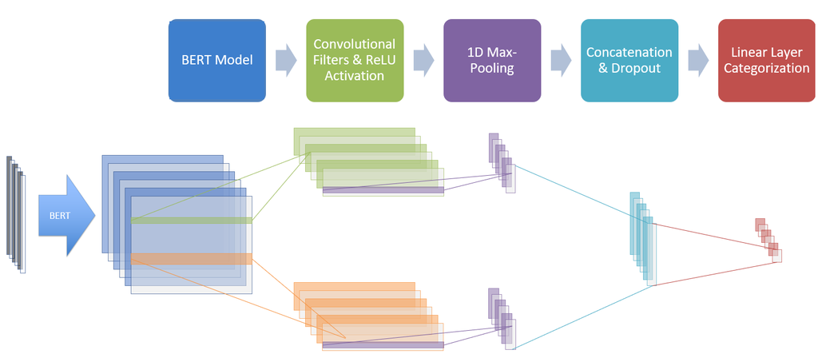

Figure 4: Graphical representation of the base BERT-CNN model to predict major policy domains

### Evaluation

We evaluate the performance of our proposed method against several baselines:

- **Multinomial Naive Bayes** (Su, Shirab, and Matwin 2011): This algorithm, commonly used in text classification, operates on the *Bag of Words assumption* and the assumption of *Conditional independence*.
- **Support Vector Machines** (Tong and Koller 2001): We used this traditional binary classifier to calculate baselines with the `SVC` package from `scikit-learn`[^5], employing a “one-against-one” approach for multi-class classification.
- **Convolutional Neural Networks (CNN)** (Kim 2014; LeCun et al. 1998): To run this deep learning model, originally designed for image classification, we first made use of pre-trained word vectors trained by GloVe, an unsupervised learning algorithm for obtaining vector representations for words (Pennington, Socher, and Manning 2014).

To evaluate model fit, we utilized *accuracy* and *loss* as key metrics to compare performance of our *CNN* baseline and our proposed models (BERT-CNN, BERT-GRU). We calculated the *F1-score* for each model that we ran. In our results, we present both the Macro-F1 score and Micro-F1 score[^6].

### Architecture fine tuning

We tested different modifications of the CNN and BERT models. For the CNN models, we compared the following modifications:

- **Stemming and Lemmatization**: We test whether stemming or lemmatizing text in the pre-processing steps improves predictions using quasi-sentences from the Manifesto Project Corpus.
- **Dropout rates**: We decreased the dropout rate from 0.5 to 0.25 to determine whether fine-tuning dropout rates yield differences in performance. This is because we initially found that our models were overfitting.
- **Additional linear layer**: An additional linear layer was added prior to the final categorization linear layer to establish whether “deeper” neural networks generate improved predictions.
- **Removal of uncategorized quasi-sentences**: We removed quasi-sentences that were labeled as “not categorized” to investigate whether predictions improve with an altered classification scheme of 7 specified policy domains and 57 policy preference codes[^7].

### Results

Table 2: Baseline, CNN and BERT models run with base model specifications as detailed in Table 1

[output not shown]

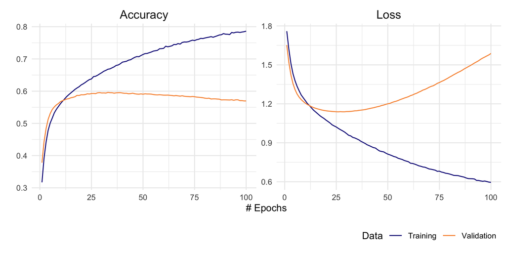

Figure 5: An illustration of overfitting in our CNN model for classifying manifesto QSs by major policy domain

### CNN and BERT Modifications

Comparing modifications to our CNN models, our results suggest that the base model outperforms most alternative model specifications. As outlined in Table 3, reducing the dropout rate to 0.25 improved the model on some indicators marginally. As expected, the removal of uncategorized quasi-sentences yielded improvements in predictions, with a significantly higher Macro-F1 score compared to other model specifications. Based on these results, future work should focus on how model predictions of uncategorized quasi-sentences can be improved, given their random nature.

Table 3: Comparing results of modifications to CNN and BERT base models for predicting policy domains

| Model | Modification | Test Loss | Test Accuracy | Micro-F1 | Macro-F1 | Epochs |
| --- | --- | --- | --- | --- | --- | --- |
| *CNN* |  |  |  |  |  |  |
|  | Base model | 1.177 | **0.589** | **0.589** | 0.466 | 100 |
|  | Lemmatized text | **1.174** | 0.585 | 0.585 | 0.46 | 100 |
|  | Stemmed text | 1.213 | 0.577 | 0.576 | 0.448 | 100 |
|  | Dropout = 0.25 | 1.177 | **0.589** | 0.588 | **0.467** | 100 |
|  | Additional layer | 1.18 | 0.586 | 0.586 | 0.462 | 100 |
|  | Removing uncategorized QSs | **1.136** | **0.596** | **0.595** | **0.535** | 100 |
| *BERT-GRU* |  |  |  |  |  |  |
|  | Base model | **1.152** | **0.594** | **0.593** | **0.479** | 10 |
|  | Training emb | 1.163 | 0.592 | 0.592 | **0.479** | 10 |
|  | Recurrent runs, training | 1.234 | 0.582 | 0.581 | 0.459 | 30 |
|  | Large, uncased | 1.172 | 0.592 | 0.591 | 0.469 | 10 |
| *BERT-CNN* |  |  |  |  |  |  |
|  | Base model | 1.166 | **0.591** | **0.591** | **0.473** | 10 |
|  | Training emb | 1.167 | 0.587 | 0.587 | 0.458 | 10 |
|  | Recurrent runs, training | **1.157** | 0.589 | 0.589 | 0.468 | 30 |
|  | Large, uncased | 1.192 | 0.58 | 0.58 | 0.45 | 10 |

While we observed some improvements with modifications to the CNN model, we find that our base BERT models performed best compared to other fine-tuned modifications to model architecture. The results of our base BERT model and alternative model specifications are shown in Table 3. Even though it is possible that our base BERT model is best for this classification model, our results could also indicate the presence of over-fitting or the lack of sufficient training available given the low number of epochs.

## Limitations and Analysis

As shown in Figure 5, we observed overfitting with our major policy domain classification models. Despite employing changes and modifications to our models, including varied dropout rates, architecture fine-tuning and different learning rates, we did not find any variants of the models employed in analysis that would yield significant improvements in performance. We posit that potential improvements on these issues could be resolved by employing transfer learning and appending our sample of English-language manifestos with other political documents, such as debate transcripts.

In contrast, as shown in Figure 6, we observed little over-fitting in our minor policy domain classification models. Our classifier could benefit from employing transfer learning and appending our sample of manifesto quasi-sentences with other political texts, especially for policy domains with relatively fewer quasi-sentences to train on. It is also important to note that, compared to the more computationally intensive neural networks and deep language representation models, our Multinomial Bayes and SVM baselines did not perform significantly worse. In fact, for the minor categories, the SVM yielded superior performance in some metrics compared to that of the neural network models. Notwithstanding the lack of training of certain models, this may suggest that increasing the model complexity and consequently the computational power required may not necessarily lead to increased model performance.

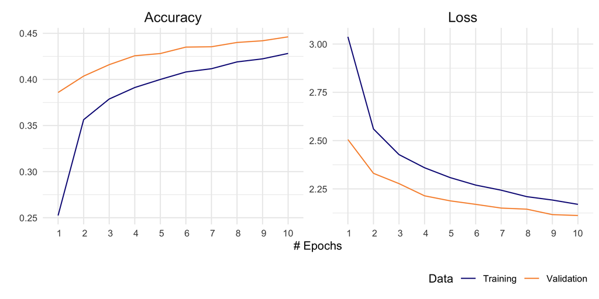

Figure 6: Training and validation metrics for the BERT-CNN model for classifying English language manifestos by policy preference

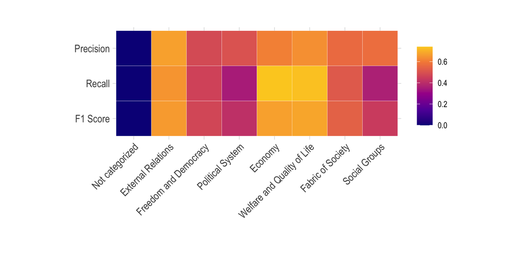

Figure 7: Average precision, recall, and Macro-F1 scores by major policy domain across all models

## Conclusion

There are several avenues for future work on neural networks and deep language representation models for automatically labeling political texts. For instance, investigating the features of individual categories that demonstrate superior performance would shed light on how we can incorporate additional features of texts to improve model performance. This area of research would also benefit from better understanding how we can filter out texts that do not fall into a particular classification scheme. Knowledge on how these issues could be resolved to improve model performance would allow for extensions in the application of deep learning models for classifying political texts.

Abercrombie, Gavin, and Riza Batista-Navarro. 2018. “A Sentiment-Labelled Corpus of Hansard Parliamentary Debate Speeches.” In *Proceedings of the Eleventh International Conference on Language Resources and Evaluation (LREC 2018). Ed. By Darja Fišer, Maria Eskevich, and Franciska de Jong. Miyazaki, Japan: European Language Resources Association (ELRA)*.

Abercrombie, Gavin, Federico Nanni, Riza Theresa Batista-Navarro, and Simone Paolo Ponzetto. 2019. “Policy Preference Detection in Parliamentary Debate Motions.” In *Proceedings of the 23rd Conference on Computational Natural Language Learning (CoNLL)*, 249–59.

Cho, Kyunghyun, Bart Van Merriënboer, Caglar Gulcehre, Dzmitry Bahdanau, Fethi Bougares, Holger Schwenk, and Yoshua Bengio. 2014. “Learning Phrase Representations Using RNN Encoder-Decoder for Statistical Machine Translation.” *arXiv Preprint arXiv:1406.1078*.

Chung, Junyoung, Caglar Gulcehre, KyungHyun Cho, and Yoshua Bengio. 2014. “Empirical Evaluation of Gated Recurrent Neural Networks on Sequence Modeling.” *arXiv Preprint arXiv:1412.3555*.

Devlin, Jacob, Ming-Wei Chang, Kenton Lee, and Kristina Toutanova. 2018. “BERT: Pre-Training of Deep Bidirectional Transformers for Language Understanding.” http://arxiv.org/abs/1810.04805.

Gilardi, Fabrizio, Katharina Füglister, and Stéphane Luyet. 2009. “Learning from Others: The Diffusion of Hospital Financing Reforms in OECD Countries.” *Comparative Political Studies* 42 (4): 549–73.

Glavaš, Goran, Federico Nanni, and Simone Paolo Ponzetto. 2017. “Cross-Lingual Classification of Topics in Political Texts.” In. Association for Computational Linguistics (ACL).

Kanai, Sekitoshi, Yasuhiro Fujiwara, and Sotetsu Iwamura. 2017. “Preventing Gradient Explosions in Gated Recurrent Units.” In *Advances in Neural Information Processing Systems*, 435–44.

Kim, Yoon. 2014. “Convolutional Neural Networks for Sentence Classification.” *CoRR* abs/1408.5882. http://arxiv.org/abs/1408.5882.

Krause, Rachel M. 2011. “Policy Innovation, Intergovernmental Relations, and the Adoption of Climate Protection Initiatives by US Cities.” *Journal of Urban Affairs* 33 (1): 45–60.

Laver, Michael, Kenneth Benoit, and John Garry. 2003. “Extracting Policy Positions from Political Texts Using Words as Data.” *American Political Science Review* 97 (2): 311–31.

LeCun, Yann, Léon Bottou, Yoshua Bengio, and Patrick Haffner. 1998. “Gradient-Based Learning Applied to Document Recognition.” *Proceedings of the IEEE* 86 (11): 2278–2324.

Nanni, Federico, Goran Glavas, Simone Paolo Ponzetto, and Heiner Stuckenschmidt. 2019. “Political Text Scaling Meets Computational Semantics.” *arXiv Preprint arXiv:1904.06217*.

Nanni, Federico, Cäcilia Zirn, Goran Glavas, Jason Eichorst, and Simone Paolo Ponzetto. 2016. “TopFish: Topic-Based Analysis of Political Position in US Electoral Campaigns.”

Pennington, Jeffrey, Richard Socher, and Christopher D. Manning. 2014. “GloVe: Global Vectors for Word Representation.” In *Empirical Methods in Natural Language Processing (EMNLP)*, 1532–43. http://www.aclweb.org/anthology/D14-1162.

Proksch, Sven-Oliver, and Jonathan B Slapin. 2010. “Position Taking in European Parliament Speeches.” *British Journal of Political Science* 40 (3): 587–611.

Simmons, Beth A, and Zachary Elkins. 2004. “The Globalization of Liberalization: Policy Diffusion in the International Political Economy.” *American Political Science Review*, 171–89.

Su, Jiang, Jelber S Shirab, and Stan Matwin. 2011. “Large Scale Text Classification Using Semi-Supervised Multinomial Naive Bayes.” In *Proceedings of the 28th International Conference on Machine Learning (ICML-11)*, 97–104. Citeseer.

Tong, Simon, and Daphne Koller. 2001. “Support Vector Machine Active Learning with Applications to Text Classification.” *Journal of Machine Learning Research* 2 (Nov): 45–66.

Volkens, Andrea, Onawa Lacewell, Pola Lehmann, Sven Regel, Henrike Schultze, and Annika Werner. 2019. “The Manifesto Data Collection. Manifesto Project (MRG/CMP/MARPOR).” *Berlin: Wissenschaftszentrum Berlin für Sozialforschung (WZB)*.

Zirn, Cäcilia, Goran Glavas, Federico Nanni, Jason Eichorts, and Heiner Stuckenschmidt. 2016. “Classifying Topics and Detecting Topic Shifts in Political Manifestos.”